# Week02_Wednesday slides

## Week 02 Wednesday

February 04, 2026

## Announcements

1. A02 (Webots Tutorials) is due **Today**
2. A01 (reaction paper) is due **This Friday**
3. A03 (robot programming 1) is due **Friday, February 13**

## Goals

1. A03 discussion
2. FSM example(s)

## A03 discussion

A03 asks you to make the Romi move and collect/plot some data. We will program Romis **directly in Arduino**. There is a section on how to do this, along with an example code to get you started, **here** in 02A_Romi_Resources. A03 is about collecting some initial data to help you **scope a dynamic model** of Romi.

**Do not try to interface with the Romi using Python or Bluetooth for this assignment.**

[interactive chart not shown]

## Finite State Machine Example: Romi "Box"

For the class exercise you completed, we could say that the Romi is either "going straight" or "turning". Drawing these two states is the first step in our design.

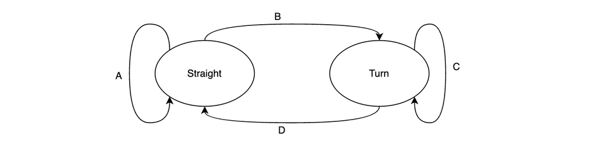

Finally, we can decide what stimuli will cause these transitions and fill out our table.

| **Transition** | **Start** | **Condition** | **End** |
| --- | --- | --- | --- |
| A | straight | change in distance < L | straight |
| B | straight | change in distance >= L | turn |
| C | turn | change in angle < 90 | turn |
| D | turn | change in angle >= 90 | straight |

## Let's re-configure this table to allow us to "test" the FSM using the keyboard!

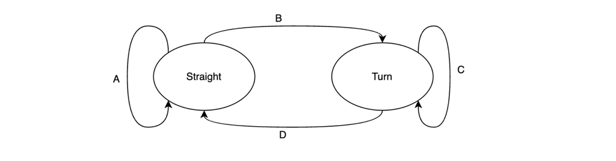

| **Transition** | **Start** | **Condition** | **End** |
| --- | --- | --- | --- |
| A | straight | not press 'k' | straight |
| B | straight | press 'k' | turn |
| C | turn | not press 'k' | turn |
| D | turn | press 'k' | straight |

## From Monday: Four-Block Structure for implementation of an FSM

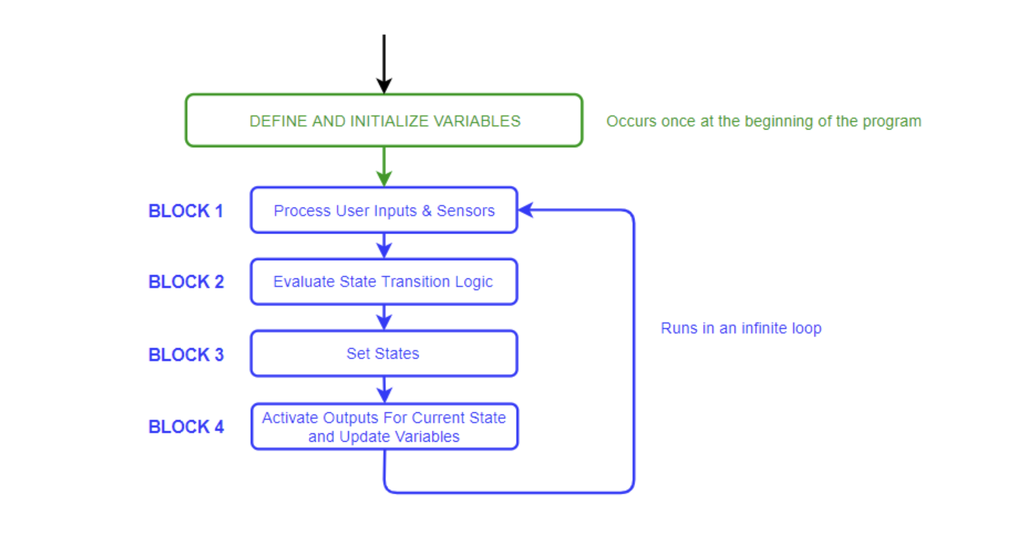

## Class Example: Block 1 to detect a "unique press"

We will use the keyboard module in Webots's "controller" python library for this exercise. Our goal is to have Webots detect a *unique* press on a specific key (in this case, the 'k' key). Documentation of the keyboard functionality in Webots is available [here](https://cyberbotics.com/doc/reference/keyboard?tab-language=python).

### Step 1: Clone a new copy of the ES302_Webots repository into your student work folder (or anywhere on your computer)

- Create a new ES302 Webots workspace using the following commands:

```
git clone https://github.com/Alexanderallenbrown/ES302_Webots.git my_folder_name
cd my_folder_name
git submodule update --init
git submodule update
```

**or, just make a copy of your last in-class exercise folder!**

### Step 2: open the romi_demo world, and modify the romi_demo controller.

After the romi is defined in the file, pull out the "keyboard" sensor instance and enable it.

```
romi = Romi(sim=True)
keyboard = romi.simromi.getKeyboard()
print(keyboard)
keyboard.enable(int(romi.simromi.getBasicTimeStep()))
```

Then, in the While loop, add functionality to print the key currently pressed.

```
while romi.simromi.step(timestep) != -1:
    print(keyboard.getKey())
```

Run the simulation, **click on the 3D window**, and then press the "k" key to see the key code corresponding with this key (75).

### Step 3: Implement a "unique press" system to detect presses on key 'k'

```
romi = Romi(sim=True)
keyboard = romi.simromi.getKeyboard()
print(keyboard)
keyboard.enable(int(romi.simromi.getBasicTimeStep()))
oldKey
...
while romi.simromi.step(timestep) != -1:
    keyNow = keyboard.getKey()
    uniqueK = (keyNow==75) and (oldKey!=75)
    oldKey = keyNow

    print(uniqueK)
```

verify that uniqueK goes 'true' **for one loop only** when 'k' is held down.

### Block 2: Evaluate State Transition Logic

To write the code for block 2, simply write a single line of code representing to the boolean expression for *each* transition in your state transition table *without including the ending state.*

## How would we implement the transitions from our 'test' FSM in code?

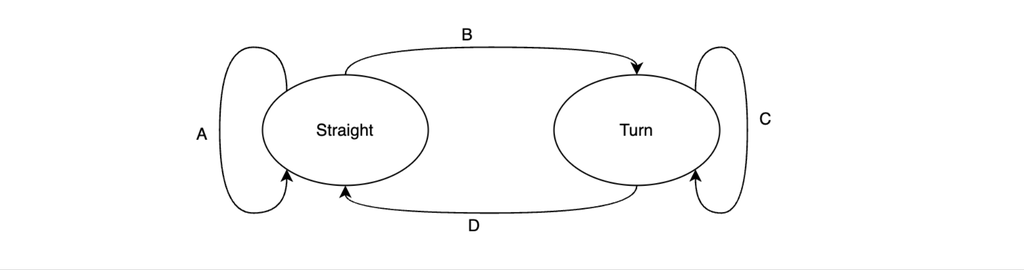

| **Transition** | **Start** | **Condition** | **End** |
| --- | --- | --- | --- |
| A | straight | not press 'k' | straight |
| B | straight | press 'k' | turn |
| C | turn | not press 'k' | turn |
| D | turn | press 'k' | straight |

## How would we implement the transitions from our 'test' FSM in code?

| **Transition** | **Start** | **Condition** | **End** |
| --- | --- | --- | --- |
| A | straight | not press 'k' | straight |
| B | straight | press 'k' | turn |
| C | turn | not press 'k' | turn |
| D | turn | press 'k' | straight |

**The Block 2 lines can be written by reading directly across the first three columns of the table!**

```
A=straight and not uniqueK
B=straight and uniqueK
C=turn and not uniqueK
D=turn and uniqueK
```

## Block 3: Set the FSM's State.

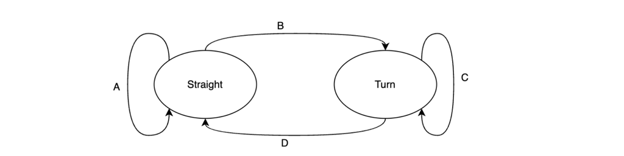

Look at each state in your diagram. The ways in which any state can be true is that any of the transitions that **point to it** are true!! This means, for our example, that block 3 looks like this:

```
straight = A or D
turn = B or C
```

### Block 4: Activate Outputs For Current State and Update Variables

Once you know what state your machine is in, you can use "if" statements to perform actions based on the state the machine is in!!

```
if(straight):
    romiGoForward()
elif(turn):
    romiTurnLeft()
else:
    print("OOPS! not in a state!)
```